# Hierarchical Models in Stan

Kelly

3/24/2020

## What’s a Hierarchical Model?

When you have a dataset that has some underlying structure – for example, perhaps you have collected many samples at different sites – there’s a good chance you would benefit from a **hierarchical model** (also called a **multilevel** model). That is, instead of lumping all data together into a single pool, you treat different parts of your dataset (somewhat) separately. This allows you to let (for example) the effect of sunlight on growth vary across your collection sites.

This is also referred to as `**mixed-effects modeling**’, because it allows you to specify that some model parameters apply across all samples (*fixed* effects) and some apply particularly to subsets of samples (*random* effects; the slope of sunlight vs. growth in the above example).

# Stan

[figure not shown]

We’re going to use Stan (https://mc-stan.org/) for Bayesian analysis of the question, and will compare three different interfaces for Stan itself. See http://mc-stan.org/rstanarm/articles/glmer.html#comparison-with-lme4, and http://mc-stan.org/rstanarm/articles/pooling.html, in particular.

- The `rethinking` package comes with ulam(), a reasonably friendly way to generate Stan code
- The `rstanarm` package, which has pre-compiled Stan code you access by calling functions analogous to lm()
- Direct coding of a Stan input file, for comparison

## The first dataset

Following McElreath’s Statistical Rethinking book, we’ll first use the UC Berkeley admissions dataset.

See ?UCBAdmissions:

"This data set is frequently used for illustrating Simpson’s paradox, see Bickel et al (1975). At issue is whether the data show evidence of sex bias in admission practices. There were 2691 male applicants, of whom 1198 (44.5%) were admitted, compared with 1835 female applicants of whom 557 (30.4%) were admitted. This gives a sample odds ratio of 1.83, indicating that males were almost twice as likely to be admitted. In fact, graphical methods (as in the example below) or log-linear modelling show that the apparent association between admission and sex stems from differences in the tendency of males and females to apply to the individual departments (females used to apply more to departments with higher rejection rates).

Bickel, P. J., Hammel, E. A., and O’Connell, J. W. (1975). Sex bias in graduate admissions: Data from Berkeley. Science, 187, 398–403. http://www.jstor.org/stable/1739581. "

Because this is about admissions – that is, a process in which an applicant is either admitted or not – we model it as a *binomial* process. The research question is: is there evidence of sex-bias in admissions here?

```r
# prep data; from Statistical Rethinking
  data( UCBadmit )
  UCBadmit$male <- as.integer(UCBadmit$applicant.gender=="male")
  UCBadmit$dept <- rep( 1:6 , each=2 )
  UCBadmit$applicant.gender <- NULL
```

# A Naïve First Look

Lumping all the data together, it seems that males (`male = 1`) were admitted at a higher rate than those not identifying as males (`male = 0`).

```r
UCBadmit %>%
  group_by(male) %>%
  summarise(admit = sum(admit),
            applications = sum(applications)) %>%
  mutate(rate = admit / applications,
         male = as.factor(male))
```

```
## # A tibble: 2 x 4
##   male  admit applications  rate
##   <fct> <int>        <int> <dbl>
## 1 0       557         1835 0.304
## 2 1      1198         2691 0.445
```

But there’s clearly something else going on: breaking this down by department, we see a different pattern. There’s no general trend across departments.

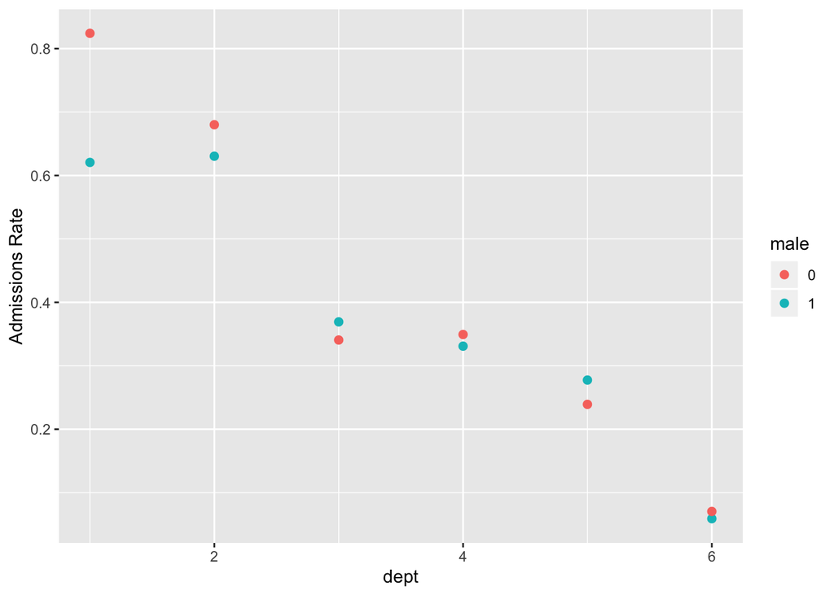

```r
UCBadmit %>%
  mutate(rate = admit / applications,
         male = as.factor(male)) %>%
  ggplot(aes(x = dept, y = rate, color = male)) +
    geom_point(size = 2) +
    ylab("Admissions Rate")
```

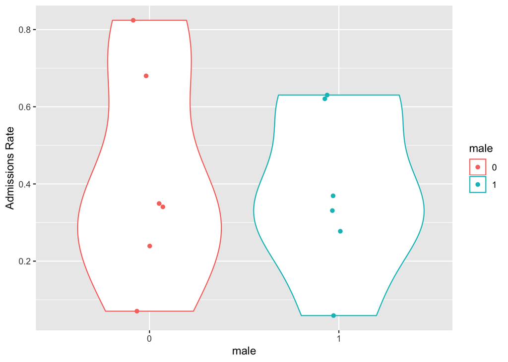

```r
UCBadmit %>%
  mutate(rate = admit / applications,
         male = as.factor(male)) %>%
  ggplot(aes(x = male, y = rate, color = male)) +
    geom_violin() +
    geom_jitter(height = 0, width = 0.1) +
    ylab("Admissions Rate")
```

So, can we quantify this? Is there ANY general evidence of sex-biased admissions?

Here’s where hierarchical models come in: our dataset is structured, with admissions happening within departments.

# Always Look at Your Data a Lot

Models aren’t magic, and neither are computers. They can only do what you ask them to do. And the more thought you put into your design – the more you see a model as a test of an idea – the better-off you’ll be. So look back at the plots above, and consider what you want to know. Are there other models you might want to build? Other possible explanations for the patterns you see in the data? Etc.

# Model with Variable Intercepts and a Single Slope

We’re treating admissions as a binomial process, so:

$Nadmitted \sim Binomial(Napplications, ProbAdmission)$

But because admissions happen within departments, we’re going to have separate admissions rates for each department. These will be our Intercept Parameters

AND because we want to know whether there’s an effect of sex, we are going test that hypothesis explicitly: if there’s an effect of sex on admissions, the “slope” parameter will be non-zero. [For what it’s worth, as my friend Ole points out, the effect of Sex isn’t really a slope parameter, because the variable takes on discrete levels (0,1 or male/female). Hence, I’m putting “slope” in quotation marks, but we’ll still call it a slope, because it illustrates the point we’re making: it’s the effect of sex on admissions probability.]

So we’ll model $ProbAdmission = Intercept[DepartmentSpecific] + Slope * Sex$

## Using Ulam()

The `ulam()` function from the `rethinking` package generates underlying Stan code for your model, compiles it in C++, and runs it. This takes a while, but is reasonably friendly. This example is from the 2nd edition of Statistical Rethinking. [And another note here from Ole. Stan uses a version of Markov Chain Monte Carlo (MCMC) to sample the probability distribution of model parameters. I think of most statistical problems in two parts, 1) what is the model I want? and 2) how do I estimate it? MCMC is clearly the later… but not the only way to do this.]

```r
m_glmm1 <- ulam(
  alist(
    admit ~ binomial(applications,p),  #just as we set it up, above: number of admits is a draw from the number of applications with probability p of success
    logit(p) <- a[dept] + b*male,      #and here's how we model p ; as above, with department-specific intercept and a single slope.  The logit() is a transform to get it to fall between 0 and 1, as probabilities must.
    a[dept] ~ normal( abar , sigma ),  #this is a Bayesian prior; we're drawing values of intercepts from a normal distribution ...
    abar ~ normal( 0 , 4 ),     #... and the parameters of that normal distribution are this mean
    sigma ~ half_normal(0,1),   #... and this variance
    b ~ normal(0,1)             #and here's the prior for our slope parameter
  ),
  data=UCBadmit,                #this is the dataset itself
  chains =4                     #this is the number of indep chains the algorithm is sampling from
  )
```

```
##
...
```

```r
precis(m_glmm1, depth = 2)  #here's how to look at the result
```

```
##              mean         sd       5.5%       94.5%    n_eff     Rhat4
## a[1]   0.67729689 0.09977484  0.5189104  0.83369452 1392.968 1.0018682
## a[2]   0.62619982 0.11451073  0.4469735  0.81109251 1453.246 0.9992986
## a[3]  -0.58278055 0.07406921 -0.7010675 -0.46342467 1654.306 1.0010947
## a[4]  -0.61523858 0.08785042 -0.7568450 -0.47681019 1508.655 1.0019493
## a[5]  -1.05749035 0.09922010 -1.2128195 -0.89612730 2253.285 0.9987517
## a[6]  -2.60520278 0.15538682 -2.8620082 -2.35953990 2012.499 0.9989496
## abar  -0.57883675 0.51664782 -1.3968477  0.26805155 1921.358 1.0012501
## sigma  1.23982285 0.33055769  0.7984756  1.82553317 1367.048 1.0020057
## b     -0.09563915 0.08128497 -0.2233219  0.03399008 1060.811 1.0038371
```

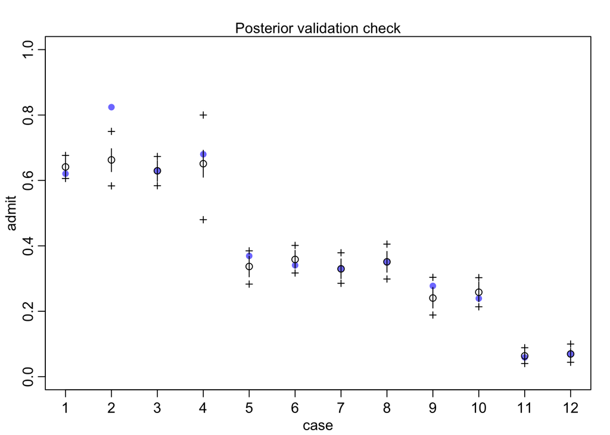

```r
postcheck(m_glmm1)          #here's a quick graphical way to compare the posteriors to the observed admissions rates
```

```r
#note: you can see the Stan code this generates using stancode(m_glmm1)
#note also: parameter values are logit-transformed, and need to be transformed back to make intuitive sense
#e.g.
#plogis(-.1)
```

This model suggests our slope – the overall effect of sex, across all departments – is very slightly negative, but the 95% CI includes zero, so in some sense it’s not significantly different from zero.

## Using rstanarm()

We can do the same thing with a different interface to Stan, with `rstanarm`. This doesn’t require compiling, so is faster. But it uses a different syntax.

```r
#make sure we're treating the appropriate variables as factors, not integers
UCBadmit2 <- UCBadmit %>%
    mutate(dept = as.factor(dept),
           male = as.factor(male))

rstanarm_variableIntercept <- stan_glmer(
  cbind(admit, reject) ~ male + (1 | dept), #this syntax is not intuitive to me. the response variable is two columns: admits and rejections, and here we specify that we want a single slope (for `male`) and a variable intercept that varies by department (`dept`). This syntax is the same as for the `lmer` package (see https://stats.stackexchange.com/questions/13166/rs-lmer-cheat-sheet)
#### OLE: This syntax always messes with me too. Again I think it's easier to interpret as intercepts because male and dept are both factors / offsets.  (1| factor) means randomness around the intercept with realizations for each level determined by factor.

  data = UCBadmit2,  #dataset
  family = binomial(link = "logit")  #since glmer is a general-purpose function, it doesn't necessarily know we're trying to do a binomial model, so we have to tell it.
  )
```

```
##
...
```

```r
summary(rstanarm_variableIntercept)
```

```
##
## Model Info:
##  function:     stan_glmer
##  family:       binomial [logit]
##  formula:      cbind(admit, reject) ~ male + (1 | dept)
##  algorithm:    sampling
##  sample:       4000 (posterior sample size)
##  priors:       see help('prior_summary')
##  observations: 12
##  groups:       dept (6)
...
```

We can compare these to the `ulam()` results; they are very similar. So that’s nice.

```r
#compare to m_glmm1 ; they agree!
m_glmm1@stanfit
```

```
## Inference for Stan model: c27cea3a38fff8c6dc8d7fa7d74fa4a1.
## 4 chains, each with iter=1000; warmup=500; thin=1;
## post-warmup draws per chain=500, total post-warmup draws=2000.
##
##           mean se_mean   sd     2.5%      25%      50%      75%    97.5% n_eff
## a[1]      0.68    0.00 0.10     0.48     0.61     0.68     0.74     0.87  1393
## a[2]      0.63    0.00 0.11     0.40     0.55     0.63     0.70     0.85  1453
## a[3]     -0.58    0.00 0.07    -0.72    -0.63    -0.58    -0.53    -0.44  1654
## a[4]     -0.62    0.00 0.09    -0.79    -0.67    -0.62    -0.56    -0.44  1509
## a[5]     -1.06    0.00 0.10    -1.25    -1.12    -1.06    -0.99    -0.86  2253
## a[6]     -2.61    0.00 0.16    -2.93    -2.70    -2.60    -2.50    -2.31  2012
## abar     -0.58    0.01 0.52    -1.60    -0.92    -0.58    -0.23     0.43  1921
## sigma     1.24    0.01 0.33     0.72     1.01     1.18     1.42     2.05  1367
## b        -0.10    0.00 0.08    -0.25    -0.15    -0.10    -0.04     0.07  1061
## lp__  -2602.42    0.07 2.12 -2607.46 -2603.60 -2602.12 -2600.81 -2599.25   823
##       Rhat
## a[1]     1
## a[2]     1
## a[3]     1
## a[4]     1
## a[5]     1
## a[6]     1
## abar     1
## sigma    1
## b        1
## lp__     1
##
## Samples were drawn using NUTS(diag_e) at Wed Mar 25 21:02:43 2020.
## For each parameter, n_eff is a crude measure of effective sample size,
## and Rhat is the potential scale reduction factor on split chains (at
## convergence, Rhat=1).
```

```r
coefficients(rstanarm_variableIntercept)
```

```
## $dept
##   (Intercept)      male1
## 1   0.6584439 -0.0942448
## 2   0.6161354 -0.0942448
## 3  -0.5910748 -0.0942448
## 4  -0.6254604 -0.0942448
## 5  -1.0626635 -0.0942448
## 6  -2.6041252 -0.0942448
##
## attr(,"class")
## [1] "coef.mer"
```

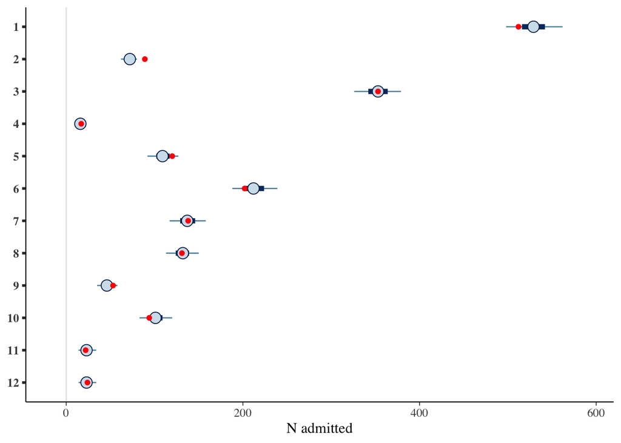

```r
# and compare predicted to observed data
posterior_predict(rstanarm_variableIntercept) %>%
  mcmc_intervals() +
  xlab("N admitted") +
  geom_point(data = UCBadmit2, aes(x = admit, y = 12:1), color = "red") #add observed data in red
```

# Stan Code Itself

Of course, the most hardcore way of using Stan is to code the input file yourself. This is also the best way to make sure you know what you’re doing. But it is another language to learn.

Here, we’ll cheat for now, annotate the code generated by `ulam()`, and use that. We need to write out a file to the computer in order to use it to run Stan. This then gets compiled in C++, the model run, and then read into **R**. It’s just a plaintext file, so you can write your own in a text editor, or in Rstudio, etc.

```r
VariableInterceptSingleSlope <-
"data{
    int reject[12];          //setting up the input data, so Stan knows what to expect. here, integer vector called `reject`, which is 12 values long. The other parts of the data block are the same.
    int applications[12];
    int admit[12];
    int male[12];
    int dept[12];
}
parameters{
    vector[6] a;             //similarly, expressly setting up the model parameters to estimate
    real abar;
    real<lower=0> sigma;
    real b;
}
model{
    vector[12] p;
    b ~ normal( 0 , 1 );       //prior for the slope
    sigma ~ normal( 0 , 1 );   //prior for the variance of distrib for intercepts. Note that a variance can't be zero, and so here a half-normal distribution is specified by constraining the parameter sigma (in the `parameters` block) not to go below zero.
    abar ~ normal( 0 , 4 );    //prior for the mean of distrib for intercepts
    a ~ normal( abar , sigma );  //prior for the distribution of intercepts
    for ( i in 1:12 ) {     // for each set of observations, use a and b to estimate probability of admission
        p[i] = a[dept[i]] + b * male[i];
        p[i] = inv_logit(p[i]);
    }
    admit ~ binomial( applications , p );  //finally, infer probability of admission, given data
}
"

#write out to file
write.table(VariableInterceptSingleSlope, "VariableInterceptSingleSlope.stan", row.names = F, quote = F, col.names = F)

#then read in and run Stan
model_varInt <- stan(file = "VariableInterceptSingleSlope.stan",
                     data = UCBadmit,  #note here: it wants integers, not factors, for key variables
                     chains = 4,   #number of chains
                     iter = 4000   #number of iterations per chain
       )
```

```
##
...
```

```r
#here again, the model results are the same, which of course they should be
summary(model_varInt)$summary
```

```
##                mean      se_mean         sd          2.5%           25%
## a[1]   6.745700e-01 0.0015033669 0.09769052     0.4893194     0.6083333
## a[2]   6.285027e-01 0.0016839068 0.11434957     0.4075581     0.5502281
## a[3]  -5.842591e-01 0.0008994159 0.07537257    -0.7303449    -0.6346362
## a[4]  -6.158454e-01 0.0010864651 0.08475324    -0.7838469    -0.6739101
## a[5]  -1.059036e+00 0.0011082000 0.09965595    -1.2570820    -1.1265430
## a[6]  -2.602665e+00 0.0018777029 0.15619359    -2.9158246    -2.7056587
## abar  -5.872874e-01 0.0069754517 0.53874969    -1.6193540    -0.9224001
## sigma  1.256406e+00 0.0043272570 0.34556639     0.7499974     1.0008282
## b     -9.503157e-02 0.0013639329 0.07937594    -0.2517020    -0.1481492
...
```

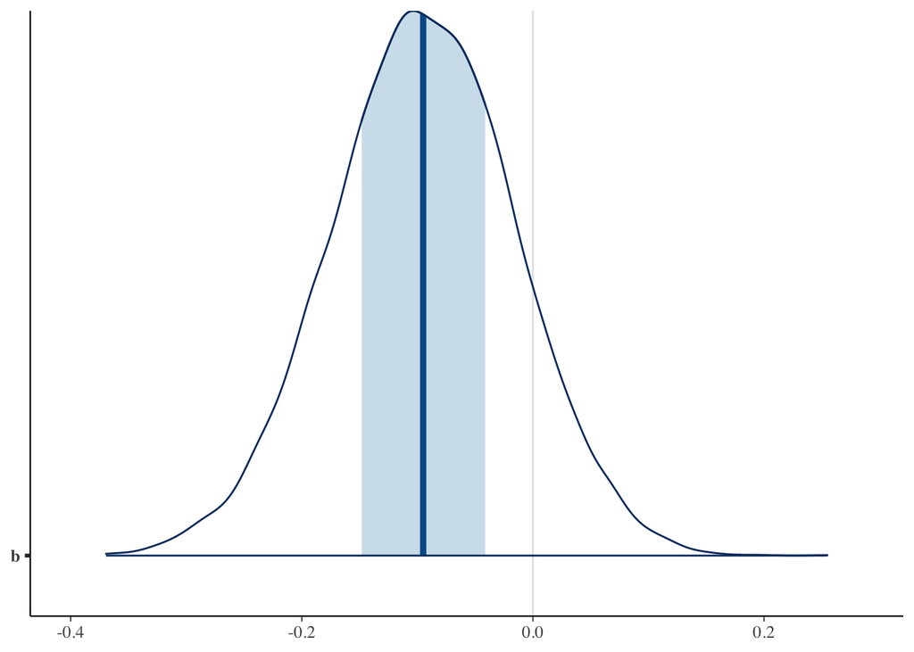

```r
#as with the earlier versions, we can look at the posterior densities for individual parameters -- here, the slope parameter for sex.
mcmc_areas(model_varInt, pars = "b")
```

And why would you want to use Stan code? Well, apart from making sure you know what your computer is doing, it also offers the ability to create downstream “generated quantities”. For example, suppose you wanted to use your estimated parameters to project admissions in a hypothetical admissions class for some future year. You could use Stan’s generated quantities block (not illustrated in the example above, because we didn’t use it) to derive predictions and credibility intervals for those predictions. Which is pretty cool.

# Model with Variable Intercepts and Variable Slopes

OK, so it seems like the department-level variation in baseline admission rate (i.e., the intercept) explains a lot. But we can also let the slope (here, effect of sex on admissions rate) vary with department. The cost is estimating a lot more parameters, but it turns out to be worthwhile.

## Using Ulam

This is now a lot more complicated, because the department-level slope and intercept parameters aren’t independent of one another… they come from the same departments, after all. This means the code is less straightforward. But the result is intelligible.

```r
m_glmm2 <- ulam(
  alist(
    admit ~ binomial(applications,p),
    logit(p) <- a[dept] + b[dept]*male,
    c( a , b )[dept] ~ multi_normal( c(abar,bbar) , Rho , sigma ),
    abar ~ normal( 0 , 4 ),
    bbar ~ normal(0,1),
    sigma ~ half_normal(0,1),
    Rho ~ lkjcorr(2)
  ),
  data=UCBadmit,
  chains = 4)
```

```
##
...
```

## Using rstanarm

```r
  #adapted from  http://mc-stan.org/rstanarm/articles/pooling.html
  SEED <- 101
  wi_prior <- normal(-1, 1)  # weakly informative prior on log-odds

 rstanarm_variableSlopeIntercept <- stan_glmer(
  cbind(admit, reject) ~ (1 + male | dept), #a different slope and intercept for each dept and male/nonmale
           data = UCBadmit2,
           family = binomial("logit"),
           prior_intercept = wi_prior,
  seed = SEED)
```

```
##
...
```

```r
  #compare to m_glmm2; they also agree!
m_glmm2@stanfit
```

```
## Inference for Stan model: 7229198d25d85b8326e772291566e9fb.
## 4 chains, each with iter=1000; warmup=500; thin=1;
## post-warmup draws per chain=500, total post-warmup draws=2000.
##
##              mean se_mean   sd     2.5%      25%      50%      75%    97.5%
## b[1]        -0.69    0.06 0.31    -1.28    -0.91    -0.71    -0.49    -0.08
## b[2]        -0.19    0.01 0.29    -0.79    -0.38    -0.16    -0.02     0.40
## b[3]         0.06    0.01 0.14    -0.18    -0.05     0.05     0.15     0.35
## b[4]        -0.09    0.00 0.13    -0.36    -0.18    -0.08    -0.02     0.17
## b[5]         0.09    0.01 0.18    -0.23    -0.04     0.08     0.21     0.47
...
```

```r
coefficients(rstanarm_variableSlopeIntercept)
```

```
## $dept
##          male1 (Intercept)
## 1 -0.747500898   1.2656229
## 2 -0.159820936   0.6862743
## 3  0.095567018  -0.6607737
## 4 -0.075048393  -0.6307233
## 5  0.149863447  -1.1449459
## 6 -0.003275237  -2.6489078
##
## attr(,"class")
...
```

Now compare predicted to observed data…

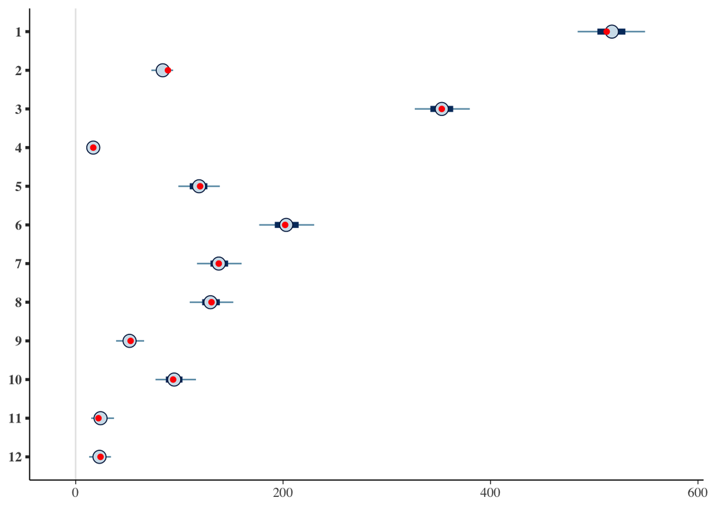

```r
posterior_predict(rstanarm_variableSlopeIntercept) %>%
  mcmc_intervals() +
  geom_point(data = UCBadmit2, aes(x = admit, y = 12:1), color = "red") #add observed data in red
```

## Stan Code Itself

I’m not going to pretend I can code this myself yet, because of the complications of correlations among parameters (and thus, the requirement for a correlation matrix).

So I will just put the output of `stancode()` for the `ulam()` object above, and you can check it out.

```r
stancode(m_glmm2)
```

```
## data{
##     int reject[12];
##     int applications[12];
##     int admit[12];
##     int male[12];
##     int dept[12];
## }
## parameters{
##     vector[6] b;
##     vector[6] a;
##     real abar;
##     real bbar;
##     vector<lower=0>[2] sigma;
##     corr_matrix[2] Rho;
## }
## model{
##     vector[12] p;
##     Rho ~ lkj_corr( 2 );
##     sigma ~ normal( 0 , 1 );
##     bbar ~ normal( 0 , 1 );
##     abar ~ normal( 0 , 4 );
##     {
##     vector[2] YY[6];
##     vector[2] MU;
##     MU = [ abar , bbar ]';
##     for ( j in 1:6 ) YY[j] = [ a[j] , b[j] ]';
##     YY ~ multi_normal( MU , quad_form_diag(Rho , sigma) );
##     }
##     for ( i in 1:12 ) {
##         p[i] = a[dept[i]] + b[dept[i]] * male[i];
##         p[i] = inv_logit(p[i]);
##     }
##     admit ~ binomial( applications , p );
## }
```

# Conclusion

And finally… is there evidence of sex-biased admissions? Not on the whole, and really only in one department (Department 1), and in that case, maleness works against applicants, rather than for them.

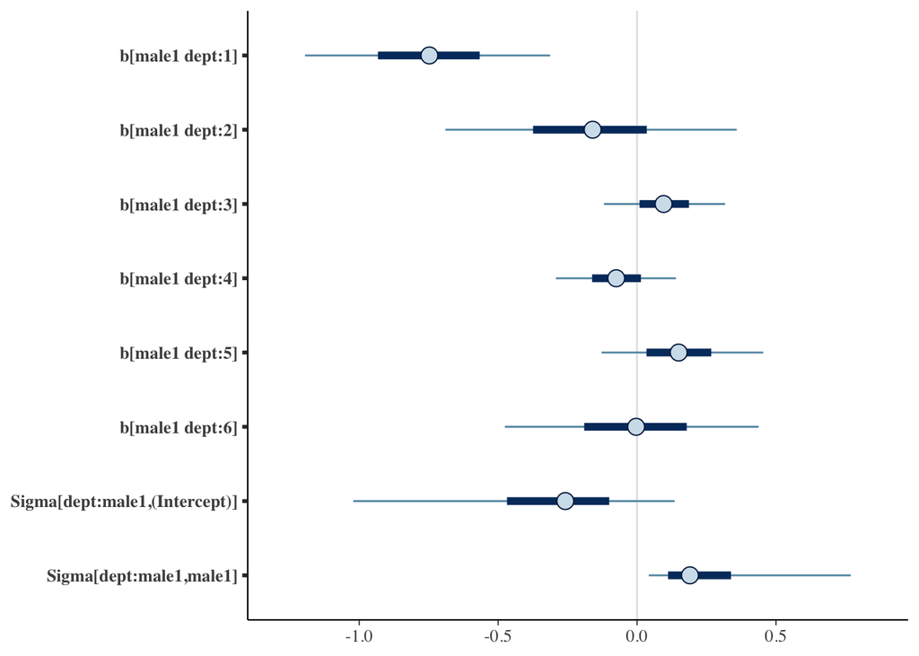

```r
mcmc_intervals(rstanarm_variableSlopeIntercept,
               regex_pars = "male1")
```

# A second example: CO2 uptake in Plants

To do a linear-regression example, we’ll look at the built-in CO2 uptake dataset.

From the helpfile: “The CO2 data frame has 84 rows and 5 columns of data from an experiment on the cold tolerance of the grass species *Echinochloa crus-galli*.”

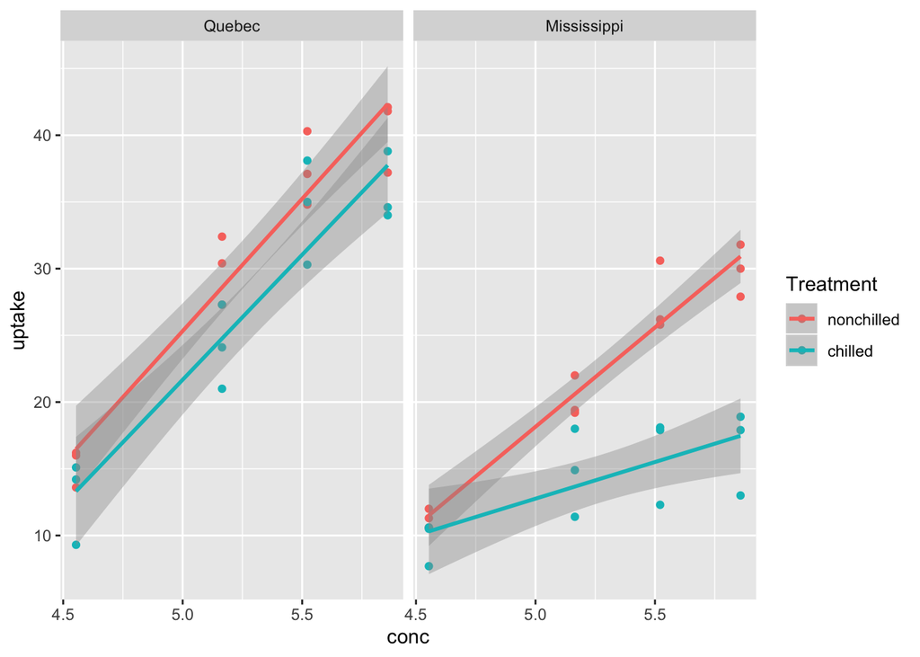

```r
#looking creating a data subset we can model with a linear regression
plants <- datasets::CO2 %>%
  filter(conc < 500) %>%    #just take the lower part of the curve
  mutate(conc = log(conc))  #log-transform concentration

#take a look at the data:
  plants %>%
  ggplot(aes(y = uptake, x = conc, color = Treatment)) +
    geom_point() +
    geom_smooth(method = "lm") +
    facet_grid(~Type)
```

So, it looks likely that there is a differential effect of plant type (Quebec vs. Mississippi) and of treatment (chilled vs. nonchilled) on CO2 uptake in these plants.

The research question is then: do the slopes vary for each of these data subsets?

We can guess that the intercept of these models will be the same for all treatments and all types, because when CO2 concentration is zero, uptake must be zero.

So we want a model that allows slope to vary by both plant type and treatment, but keeps a single intercept.

We’ll do this one with `rstanarm`.

```r
varSlope <- stan_glmer(uptake ~ (0+conc|Type/Treatment), #noting here that each plant Type has different Treatment levels... that is, they are nested.  See https://stats.stackexchange.com/questions/13166/rs-lmer-cheat-sheet and https://rpsychologist.com/r-guide-longitudinal-lme-lmer
           data = plants,
           family = "gaussian",
           prior = normal(0, 20),
           prior_intercept = normal(0, 10),
           chains = 4)
```

```
##
...
```

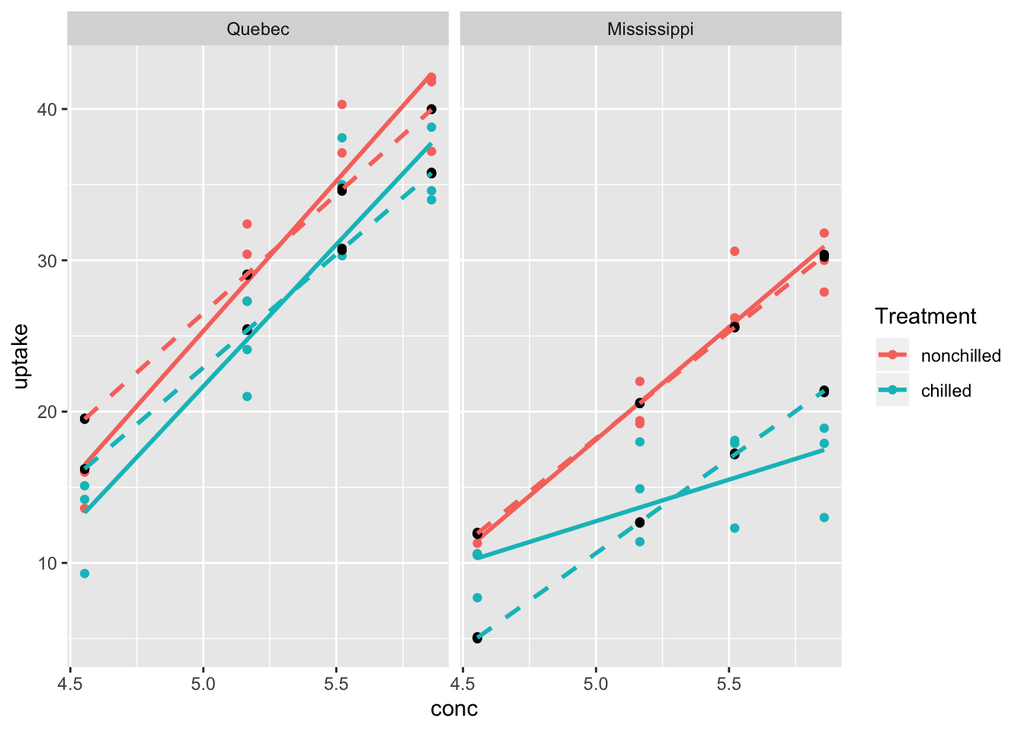

```r
#for a very quick/dirty view, just look at posterior means
plants$modelPrediction1 <-
  posterior_predict(varSlope) %>%
  colMeans()

plants %>%
  ggplot(aes(y = uptake, x = conc, color = Treatment)) +
    geom_point() +
    geom_smooth(method = "lm", se = F) +
    geom_point(aes(y = modelPrediction1, x = conc), color = "black") +
    geom_smooth(aes(y = modelPrediction1, x = conc), method = "lm", se = F, linetype = "dashed") +
    facet_grid(~Type)
```

This model does a pretty good job, but from the graph, it looks like we want to do another one, letting the intercepts vary, and see if that helps the fit.

```r
varSlopeInt <- stan_glmer(uptake ~ (1+conc|Type/Treatment),
           data = plants,
           family = "gaussian",
           prior = normal(0, 5),
           prior_intercept = normal(0, 50),
           chains = 4)
```

```
##
...
```

Still not a perfect fit. Mississippi Chilled doesn’t want to behave very well. But a bit better overall.

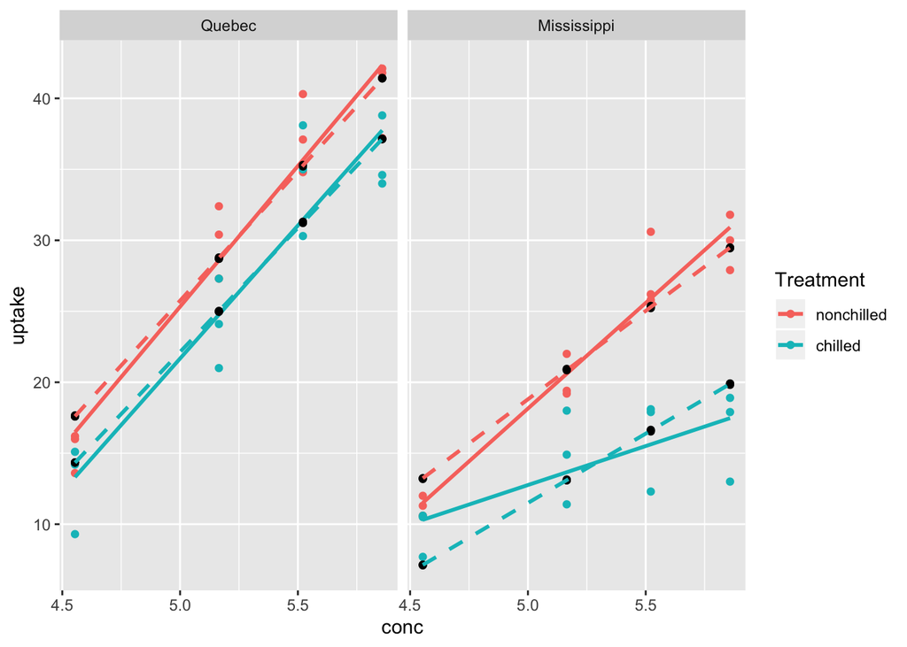

```r
#for a very quick/dirty view, just look at posterior means
plants$modelPrediction2 <-
  posterior_predict(varSlopeInt) %>%
  colMeans()

plants %>%
  ggplot(aes(y = uptake, x = conc, color = Treatment)) +
    geom_point() +
    geom_smooth(method = "lm", se = F) +
    geom_point(aes(y = modelPrediction2, x = conc), color = "black") +
    geom_smooth(aes(y = modelPrediction2, x = conc), method = "lm", se = F, linetype = "dashed") +
    facet_grid(~Type)
```

Do model comparison, to see if the gain is worth it.

```r
loo_compare(
  waic(varSlope),
  waic(varSlopeInt)
)
```

```
##             elpd_diff se_diff
## varSlopeInt  0.0       0.0
## varSlope    -6.2       1.9
```

The second model is way better (i.e., is far more probable to minimize information loss), and so we’ll use that one.

## Conclusion to Part 2

So, do the different plant types and treatments respond differently to different CO2 concentrations?

Looking at the slope parameters:

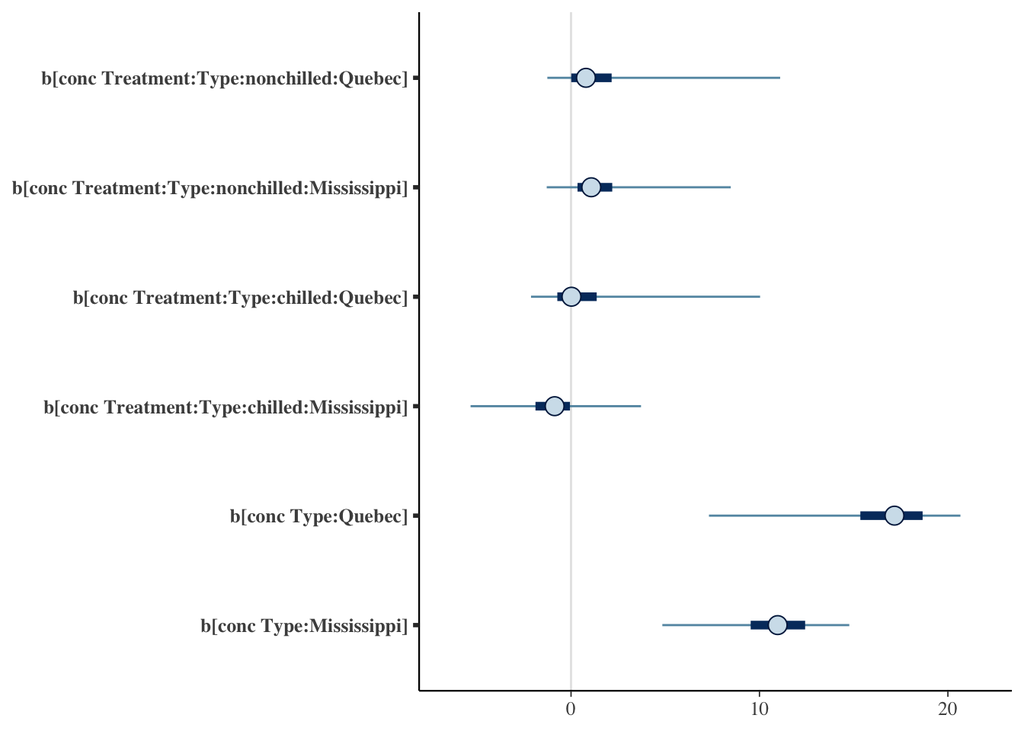

```r
mcmc_intervals(varSlopeInt,
           regex_pars = "b\\[conc")
```

1. Type matters more than Treatment, and
2. Within a Type, Treatment matters slightly more for Mississippi than for Quebec.

You can quantify this conclusion by comparing the different slope parameters:

```r
summary(varSlopeInt)
```

```
##
## Model Info:
##  function:     stan_glmer
##  family:       gaussian [identity]
##  formula:      uptake ~ (1 + conc | Type/Treatment)
##  algorithm:    sampling
##  sample:       4000 (posterior sample size)
##  priors:       see help('prior_summary')
##  observations: 48
##  groups:       Treatment:Type (4), Type (2)
##
## Estimates:
##                                                        mean   sd     10%
## (Intercept)                                           -49.6   13.3  -66.0
## b[(Intercept) Treatment:Type:nonchilled:Quebec]        -3.0    7.6  -12.0
## b[conc Treatment:Type:nonchilled:Quebec]                2.0    4.1   -0.7
## b[(Intercept) Treatment:Type:nonchilled:Mississippi]   -1.6    5.9   -8.0
## b[conc Treatment:Type:nonchilled:Mississippi]           1.8    3.1   -0.5
## b[(Intercept) Treatment:Type:chilled:Quebec]           -2.7    7.3  -10.8
## b[conc Treatment:Type:chilled:Quebec]                   1.2    4.0   -1.5
## b[(Intercept) Treatment:Type:chilled:Mississippi]       4.6    8.5   -1.0
## b[conc Treatment:Type:chilled:Mississippi]             -0.9    2.8   -3.8
## b[(Intercept) Type:Quebec]                            -12.9   14.1  -31.6
## b[conc Type:Quebec]                                    16.3    4.2   12.3
## b[(Intercept) Type:Mississippi]                         7.6   12.5   -6.1
## b[conc Type:Mississippi]                               10.7    3.1    7.6
## sigma                                                   3.3    0.4    2.8
## Sigma[Treatment:Type:(Intercept),(Intercept)]          47.1  102.7    0.3
## Sigma[Treatment:Type:conc,(Intercept)]                -10.2   34.7  -30.2
## Sigma[Treatment:Type:conc,conc]                        17.1   50.8    0.5
## Sigma[Type:(Intercept),(Intercept)]                   191.3  196.8   20.3
## Sigma[Type:conc,(Intercept)]                          -26.1   97.4 -133.7
## Sigma[Type:conc,conc]                                 168.6  142.8   52.5
##                                                        50%    90%
## (Intercept)                                           -49.7  -33.4
## b[(Intercept) Treatment:Type:nonchilled:Quebec]        -0.4    1.9
## b[conc Treatment:Type:nonchilled:Quebec]                0.8    5.9
## b[(Intercept) Treatment:Type:nonchilled:Mississippi]   -0.4    2.9
## b[conc Treatment:Type:nonchilled:Mississippi]           1.1    4.8
## b[(Intercept) Treatment:Type:chilled:Quebec]           -0.4    2.1
```

[output cut: 32 more lines]

```
## b[(Intercept) Type:Quebec]                           0.4  1.0  1108
## b[conc Type:Quebec]                                  0.2  1.0   376
## b[(Intercept) Type:Mississippi]                      0.3  1.0  1511
## b[conc Type:Mississippi]                             0.1  1.0   626
## sigma                                                0.0  1.0  3371
## Sigma[Treatment:Type:(Intercept),(Intercept)]        4.1  1.0   617
## Sigma[Treatment:Type:conc,(Intercept)]               1.1  1.0   982
## Sigma[Treatment:Type:conc,conc]                      2.4  1.0   465
## Sigma[Type:(Intercept),(Intercept)]                  4.6  1.0  1858
## Sigma[Type:conc,(Intercept)]                         2.3  1.0  1849
## Sigma[Type:conc,conc]                                3.0  1.0  2196
## mean_PPD                                             0.0  1.0  3969
## log-posterior                                        0.1  1.0  1184
##
## For each parameter, mcse is Monte Carlo standard error, n_eff is a crude measure of effective sample size, and Rhat is the potential scale reduction factor on split chains (at convergence Rhat=1).
```

By this analysis, it seems Type is a significant effect, but Treatment isn’t really.